# Bellabeat Data Analysis Case Study

Kevin Lin

11/10/2021 - 14/10/2021

## 1. Introduction

Bellabeat, a high-tech manufacturer of health-focused products for women, is a small but successful company with the potential of becoming a large paler in the global smart device market. They offer different smart devices which collects data on sleep, activity, stress, menstrual cycles, and mindfulness habits with the goal of helping users better understand their habits and make healthy decisions

The goal of this case study is to analyze smart device fitness data, which would yield new viable growth opportunities for the company.

## 2. Key Questions:

1. What are some trends in smart device usage?
2. How could these trends apply to Bellabeat customers?
3. How could these trends help influence Bellabeat marketing strategy?

### 2.1 Stakeholders

- **Urška Sršen**: Bellabeat’s cofounder and Chief Creative Officer
- **Sando Mur**: Mathematician and Bellabeat’s cofounder; key member of the Bellabeat executive team
- **Bellabeat marketing analytics team**: A team of data analysts responsible for collecting, analyzing, and reporting data that helps guide Bellabeat’s marketing strategy.

## 3. Preparation

### 3.1 Data Source - Public:

- [FitBit Fitness Tracker Data](https://www.kaggle.com/arashnic/fitbit) (CC0: Public Domain, dataset made available through Mobius)
  - Kaggle Data Set - personal fitness tracker from thirty fitbit users
- Used Data Sets
  - hourlyCalories_merged.csv
  - hourlySteps_merged.csv
  - dailyActivity_merged.csv
  - sleepDay_merged.csv

### 3.2 Privacy and Consent

These datasets were generated by respondents to a distributed survey via Amazon Mechanical Turk between 03.12.2016-05.12.2016. Thirty eligible Fitbit users consented to the submission of personal tracker data, including minute-level output for physical activity, heart rate, and sleep monitoring.

### 3.3 Potential Issues with Dataset

The data only includes 33 people which is an extremely small sample from the population that uses these smart devices. In addition, not all 33 users data is available in each file. Thus this introduces a high chance of sampling bias into our analysis.

The data was collected in 2016, thus the data is quite dated, and the habit of people using health trackers have changed significantly, thus the accuracy of the sample is likely going to be higher with current data.

### 3.4 Setting up R for Data Processing

#### 3.4.1 Loading Packages

```r
library(tidyverse)
library(here)
library(skimr)
library(janitor)
library(ggplot2)
library(lubridate)
library(ggpubr)
```

#### 3.4.2 Importing Data into R

```r
hourly_Step <- read.csv("hourlySteps_merged.csv")
daily_Activity <- read.csv("dailyActivity_merged.csv")
daily_Sleep <- read.csv("sleepDay_merged.csv")
```

#### 3.4.3 Preview Data Structure

```r
str(hourly_Step)
```

```
## 'data.frame':    22099 obs. of  3 variables:
##  $ Id          : num  1.5e+09 1.5e+09 1.5e+09 1.5e+09 1.5e+09 ...
##  $ ActivityHour: chr  "4/12/2016 12:00:00 AM" "4/12/2016 1:00:00 AM" "4/12/2016 2:00:00 AM" "4/12/2016 3:00:00 AM" ...
##  $ StepTotal   : int  373 160 151 0 0 0 0 0 250 1864 ...
```

```r
str(daily_Activity)
```

```
## 'data.frame':    940 obs. of  15 variables:
##  $ Id                      : num  1.5e+09 1.5e+09 1.5e+09 1.5e+09 1.5e+09 ...
##  $ ActivityDate            : chr  "4/12/2016" "4/13/2016" "4/14/2016" "4/15/2016" ...
##  $ TotalSteps              : int  13162 10735 10460 9762 12669 9705 13019 15506 10544 9819 ...
##  $ TotalDistance           : num  8.5 6.97 6.74 6.28 8.16 ...
##  $ TrackerDistance         : num  8.5 6.97 6.74 6.28 8.16 ...
##  $ LoggedActivitiesDistance: num  0 0 0 0 0 0 0 0 0 0 ...
##  $ VeryActiveDistance      : num  1.88 1.57 2.44 2.14 2.71 ...
##  $ ModeratelyActiveDistance: num  0.55 0.69 0.4 1.26 0.41 ...
##  $ LightActiveDistance     : num  6.06 4.71 3.91 2.83 5.04 ...
##  $ SedentaryActiveDistance : num  0 0 0 0 0 0 0 0 0 0 ...
##  $ VeryActiveMinutes       : int  25 21 30 29 36 38 42 50 28 19 ...
##  $ FairlyActiveMinutes     : int  13 19 11 34 10 20 16 31 12 8 ...
##  $ LightlyActiveMinutes    : int  328 217 181 209 221 164 233 264 205 211 ...
##  $ SedentaryMinutes        : int  728 776 1218 726 773 539 1149 775 818 838 ...
##  $ Calories                : int  1985 1797 1776 1745 1863 1728 1921 2035 1786 1775 ...
```

```r
str(daily_Sleep)
```

```
## 'data.frame':    413 obs. of  5 variables:
##  $ Id                : num  1.5e+09 1.5e+09 1.5e+09 1.5e+09 1.5e+09 ...
##  $ SleepDay          : chr  "4/12/2016 12:00:00 AM" "4/13/2016 12:00:00 AM" "4/15/2016 12:00:00 AM" "4/16/2016 12:00:00 AM" ...
##  $ TotalSleepRecords : int  1 2 1 2 1 1 1 1 1 1 ...
##  $ TotalMinutesAsleep: int  327 384 412 340 700 304 360 325 361 430 ...
##  $ TotalTimeInBed    : int  346 407 442 367 712 320 377 364 384 449 ...
```

## 4. Processing Data

### 4.1 Cleaning

#### 4.1.1 Data Completeness

First we have to check if each data set contains all the 33 users, and we see that the daily_Sleep data set only contain 24

```r
n_unique(hourly_Step$Id)
```

```
## [1] 33
```

```r
n_unique(daily_Activity$Id)
```

```
## [1] 33
```

```r
n_unique(daily_Sleep$Id)
```

```
## [1] 24
```

#### 4.1.2 Checking any duplicates

Next, check if we have any duplicated data within our data set, which we see 3 in the daily_Sleep table

```r
sum(duplicated(hourly_Step))
```

```
## [1] 0
```

```r
sum(duplicated(daily_Activity))
```

```
## [1] 0
```

```r
sum(duplicated(daily_Sleep))
```

```
## [1] 3
```

#### 4.1.3 Remove duplicates

Remove the duplicated data, and verify if everything is correct

```r
daily_Sleep <- daily_Sleep %>%
  distinct() %>%
  drop_na()

sum(duplicated(daily_Sleep))
```

```
## [1] 0
```

#### 4.1.4 Cleaning and Formating

Clean the names of the data, format all the columns to lowercase, and then match the time format for combination of dataset in the next step

```r
clean_names(hourly_Step)
clean_names(daily_Activity)
clean_names(daily_Sleep)

hourly_Step <- rename_with(hourly_Step, tolower)
daily_Activity <- rename_with(daily_Activity, tolower)
daily_Sleep <- rename_with(daily_Sleep, tolower)

hourly_Step<- hourly_Step %>%
  rename(date_time = activityhour) %>%
  mutate(date_time = as.POSIXct(date_time,format ="%m/%d/%Y %I:%M:%S %p" ))

daily_Activity <- daily_Activity %>%
  rename(date = activitydate) %>%
  mutate(date = as_date(date, format = "%m/%d/%Y"))

daily_Sleep <- daily_Sleep %>%
  rename(date = sleepday) %>%
  mutate(date = as_date(date,format ="%m/%d/%Y %I:%M:%S %p"))
```

#### 4.1.5 Verifying Data

Checking the updated data set

```r
head(hourly_Step)
```

```
##           id           date_time steptotal
## 1 1503960366 2016-04-12 00:00:00       373
## 2 1503960366 2016-04-12 01:00:00       160
## 3 1503960366 2016-04-12 02:00:00       151
## 4 1503960366 2016-04-12 03:00:00         0
## 5 1503960366 2016-04-12 04:00:00         0
## 6 1503960366 2016-04-12 05:00:00         0
```

```r
head(daily_Activity)
```

```
##           id       date totalsteps totaldistance trackerdistance
## 1 1503960366 2016-04-12      13162          8.50            8.50
## 2 1503960366 2016-04-13      10735          6.97            6.97
## 3 1503960366 2016-04-14      10460          6.74            6.74
## 4 1503960366 2016-04-15       9762          6.28            6.28
## 5 1503960366 2016-04-16      12669          8.16            8.16
## 6 1503960366 2016-04-17       9705          6.48            6.48
##   loggedactivitiesdistance veryactivedistance moderatelyactivedistance
## 1                        0               1.88                     0.55
## 2                        0               1.57                     0.69
## 3                        0               2.44                     0.40
## 4                        0               2.14                     1.26
## 5                        0               2.71                     0.41
## 6                        0               3.19                     0.78
##   lightactivedistance sedentaryactivedistance veryactiveminutes
## 1                6.06                       0                25
## 2                4.71                       0                21
## 3                3.91                       0                30
## 4                2.83                       0                29
## 5                5.04                       0                36
## 6                2.51                       0                38
##   fairlyactiveminutes lightlyactiveminutes sedentaryminutes calories
## 1                  13                  328              728     1985
## 2                  19                  217              776     1797
## 3                  11                  181             1218     1776
## 4                  34                  209              726     1745
## 5                  10                  221              773     1863
## 6                  20                  164              539     1728
```

```r
head(daily_Sleep)
```

```
##           id       date totalsleeprecords totalminutesasleep totaltimeinbed
## 1 1503960366 2016-04-12                 1                327            346
## 2 1503960366 2016-04-13                 2                384            407
## 3 1503960366 2016-04-15                 1                412            442
## 4 1503960366 2016-04-16                 2                340            367
## 5 1503960366 2016-04-17                 1                700            712
## 6 1503960366 2016-04-19                 1                304            320
```

### 4.2 Merging Data

Next, we will merge the data set together for easier analysis in the future steps. The daily activity includes daily steps and calories, which would make for interesting analysis.

```r
daily_Activity_Sleep <- merge(daily_Activity, daily_Sleep, by=c ("id", "date"))
glimpse(daily_Activity_Sleep)
```

```
## Rows: 410
## Columns: 18
## $ id                       <dbl> 1503960366, 1503960366, 1503960366, 150396036…
## $ date                     <date> 2016-04-12, 2016-04-13, 2016-04-15, 2016-04-…
## $ totalsteps               <int> 13162, 10735, 9762, 12669, 9705, 15506, 10544…
## $ totaldistance            <dbl> 8.50, 6.97, 6.28, 8.16, 6.48, 9.88, 6.68, 6.3…
## $ trackerdistance          <dbl> 8.50, 6.97, 6.28, 8.16, 6.48, 9.88, 6.68, 6.3…
## $ loggedactivitiesdistance <dbl> 0, 0, 0, 0, 0, 0, 0, 0, 0, 0, 0, 0, 0, 0, 0, …
## $ veryactivedistance       <dbl> 1.88, 1.57, 2.14, 2.71, 3.19, 3.53, 1.96, 1.3…
## $ moderatelyactivedistance <dbl> 0.55, 0.69, 1.26, 0.41, 0.78, 1.32, 0.48, 0.3…
## $ lightactivedistance      <dbl> 6.06, 4.71, 2.83, 5.04, 2.51, 5.03, 4.24, 4.6…
## $ sedentaryactivedistance  <dbl> 0, 0, 0, 0, 0, 0, 0, 0, 0, 0, 0, 0, 0, 0, 0, …
## $ veryactiveminutes        <int> 25, 21, 29, 36, 38, 50, 28, 19, 41, 39, 73, 3…
## $ fairlyactiveminutes      <int> 13, 19, 34, 10, 20, 31, 12, 8, 21, 5, 14, 23,…
## $ lightlyactiveminutes     <int> 328, 217, 209, 221, 164, 264, 205, 211, 262, …
## $ sedentaryminutes         <int> 728, 776, 726, 773, 539, 775, 818, 838, 732, …
## $ calories                 <int> 1985, 1797, 1745, 1863, 1728, 2035, 1786, 177…
## $ totalsleeprecords        <int> 1, 2, 1, 2, 1, 1, 1, 1, 1, 1, 1, 1, 1, 1, 1, …
## $ totalminutesasleep       <int> 327, 384, 412, 340, 700, 304, 360, 325, 361, …
## $ totaltimeinbed           <int> 346, 407, 442, 367, 712, 320, 377, 364, 384, …
```

### 4.3 Organizing Data

Organize the average user step, calories, sleep per day

```r
average <- daily_Activity_Sleep %>%
  group_by(id) %>%
  summarise(avg_step_daily = mean(totalsteps), avg_cal_daily = mean(calories), avg_sleep_daily = mean(totalminutesasleep))
str(average)
```

```
## tibble [24 × 4] (S3: tbl_df/tbl/data.frame)
##  $ id             : num [1:24] 1.50e+09 1.64e+09 1.84e+09 1.93e+09 2.03e+09 ...
##  $ avg_step_daily : num [1:24] 12406 7968 3477 1490 5619 ...
##  $ avg_cal_daily  : num [1:24] 1872 2978 1676 2316 1541 ...
##  $ avg_sleep_daily: num [1:24] 360 294 652 417 506 ...
```

Create columns for weekly data, which will be used during analysis

```r
average <- average %>%
  mutate(avg_step_weekly = avg_step_daily*7, avg_cal_weekly = avg_cal_daily*7, avg_sleep_weekly =avg_sleep_daily*7)

str(average)
```

```
## tibble [24 × 7] (S3: tbl_df/tbl/data.frame)
##  $ id              : num [1:24] 1.50e+09 1.64e+09 1.84e+09 1.93e+09 2.03e+09 ...
##  $ avg_step_daily  : num [1:24] 12406 7968 3477 1490 5619 ...
##  $ avg_cal_daily   : num [1:24] 1872 2978 1676 2316 1541 ...
##  $ avg_sleep_daily : num [1:24] 360 294 652 417 506 ...
##  $ avg_step_weekly : num [1:24] 86840 55774 24339 10430 39331 ...
##  $ avg_cal_weekly  : num [1:24] 13106 20844 11734 16213 10786 ...
##  $ avg_sleep_weekly: num [1:24] 2522 2058 4564 2919 3543 ...
```

Next, we can categorize each user into different type, according to their averge steps per day.

We will follow such guild lines for categorizing the data

- Active 1: less than 5,999 steps per day
- Active 2: 6,000 to 9,999 steps per day
- Active 3: more than 10,000 steps per day

```r
distribution <- average %>%
  mutate(active_level = case_when(
    avg_step_daily < 5999 ~ "Low Active",
    avg_step_daily >= 6000 & avg_step_daily < 9999 ~ "Active",
    avg_step_daily >= 10000 ~ "High Active"
  )) %>%
  mutate(sleep_level = case_when(
    avg_sleep_daily/60 <7 ~ "Low Sleep Time",
    avg_sleep_daily/60 >= 7 & avg_sleep_daily/60 < 9 ~ "Average Sleep Time",
    avg_sleep_daily/60 >= 9 ~ "High Sleep Time",
  ))
str(distribution)
```

```
## tibble [24 × 9] (S3: tbl_df/tbl/data.frame)
##  $ id              : num [1:24] 1.50e+09 1.64e+09 1.84e+09 1.93e+09 2.03e+09 ...
##  $ avg_step_daily  : num [1:24] 12406 7968 3477 1490 5619 ...
##  $ avg_cal_daily   : num [1:24] 1872 2978 1676 2316 1541 ...
##  $ avg_sleep_daily : num [1:24] 360 294 652 417 506 ...
##  $ avg_step_weekly : num [1:24] 86840 55774 24339 10430 39331 ...
##  $ avg_cal_weekly  : num [1:24] 13106 20844 11734 16213 10786 ...
##  $ avg_sleep_weekly: num [1:24] 2522 2058 4564 2919 3543 ...
##  $ active_level    : chr [1:24] "High Active" "Active" "Low Active" "Low Active" ...
##  $ sleep_level     : chr [1:24] "Low Sleep Time" "Low Sleep Time" "High Sleep Time" "Low Sleep Time" ...
```

## 5. Analyze

In addition, we will be analyzing the user’s habit of smart wearables, and conclude our findings

### 5.1 Daily Correlations

We want to look at if there is any correlation between steps, sleeps, and calories burned.

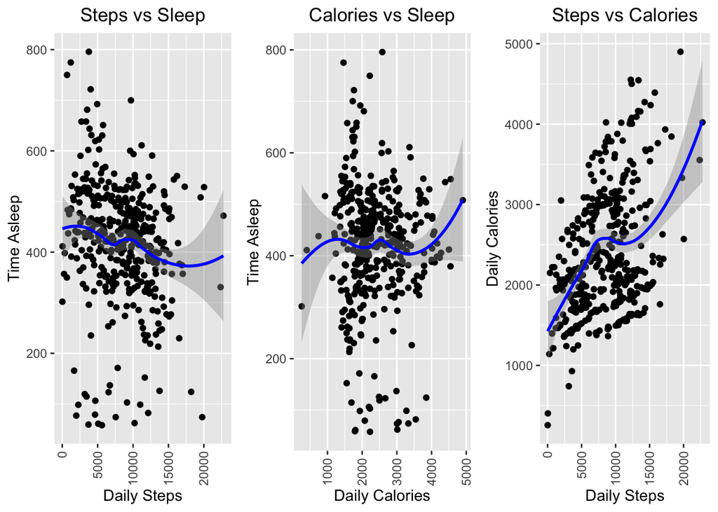

```r
p1 <- ggplot(daily_Activity_Sleep, aes(x=totalsteps, y=totalminutesasleep))+
        geom_jitter() +
        geom_smooth(color = "blue")+
        labs(x = "Daily Steps", y = "Time Asleep")+
        ggtitle("Steps vs Sleep")+
        theme(plot.title = element_text(hjust = 0.5), axis.text.x = element_text(angle = 90, vjust = 0.5, hjust=1))

p2 <- ggplot(daily_Activity_Sleep, aes(x=calories, y=totalminutesasleep))+
        geom_jitter() +
        geom_smooth(color = "blue")+
        labs(x = "Daily Calories", y = "Time Asleep")+
        ggtitle("Calories vs Sleep")+
        theme(plot.title = element_text(hjust = 0.5), axis.text.x = element_text(angle = 90, vjust = 0.5, hjust=1))

p3 <- ggplot(daily_Activity_Sleep, aes(x=totalsteps, y=calories))+
        geom_jitter() +
        geom_smooth(color = "blue")+
        labs(x = "Daily Steps", y = "Daily Calories")+
        ggtitle("Steps vs Calories")+
        theme(plot.title = element_text(hjust = 0.5), axis.text.x = element_text(angle = 90, vjust = 0.5, hjust=1))

ggarrange(p1, p2, p3, ncol = 3, nrow = 1)
```

As we can see, there like likely zero correlation between amount of steps and sleep time, as well as calories burned and sleep time. But on the other hand, we see a moderate positive correlation between amounts of steps and calories burned, which is to be expected.

### 5.2 Active Level

```r
usr_active_dis <- distribution %>%
  group_by(active_level) %>%
  summarise(total = n()) %>%
  mutate(total1 = sum(total)) %>%
  group_by(active_level) %>%
  summarise(total_percent = total / total1) %>%
  mutate(labels = scales::percent(total_percent))



head(usr_active_dis)
```

```
## # A tibble: 3 × 3
##   active_level total_percent labels
##   <chr>                <dbl> <chr>
## 1 Active               0.458 46%
## 2 High Active          0.208 21%
## 3 Low Active           0.333 33%
```

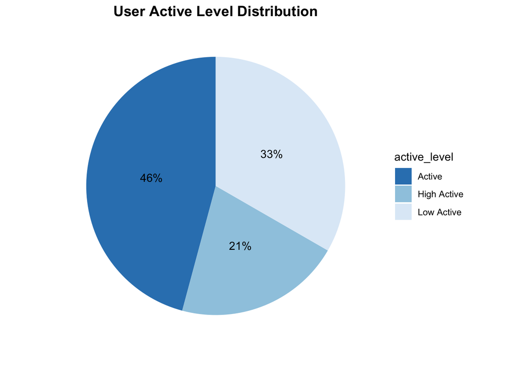

```r
dis_plot <- ggplot(usr_active_dis, aes(x="", y=total_percent, fill=active_level))+
  geom_bar(width=1,stat="identity")+
  coord_polar("y", start=0)+
  scale_fill_brewer(palette="Blues", direction=-1)+
  theme_minimal()+
  theme(axis.text.x=element_blank(),
        axis.title.y = element_blank(),
        panel.border = element_blank(),
        panel.grid=element_blank(),
        axis.ticks = element_blank(),
        plot.title=element_text(size=14, face="bold", hjust = 0.5)
        )+
  geom_text(aes(label = labels), position = position_stack(vjust = 0.5))+
  labs(title="User Active Level Distribution", x="", y="")

dis_plot
```

### 5.3 Sleep Level

```r
usr_sleep_dis <- distribution %>%
  group_by(sleep_level)%>%
  summarise(total=n())%>%
  mutate(total1=sum(total))%>%
  group_by(sleep_level)%>%
  summarise(total_percent = total/total1)%>%
  mutate(labels = scales::percent(total_percent))

head(usr_sleep_dis)
```

```
## # A tibble: 3 × 3
##   sleep_level        total_percent labels
##   <chr>                      <dbl> <chr>
## 1 Average Sleep Time        0.417  42%
## 2 High Sleep Time           0.0417 4%
## 3 Low Sleep Time            0.542  54%
```

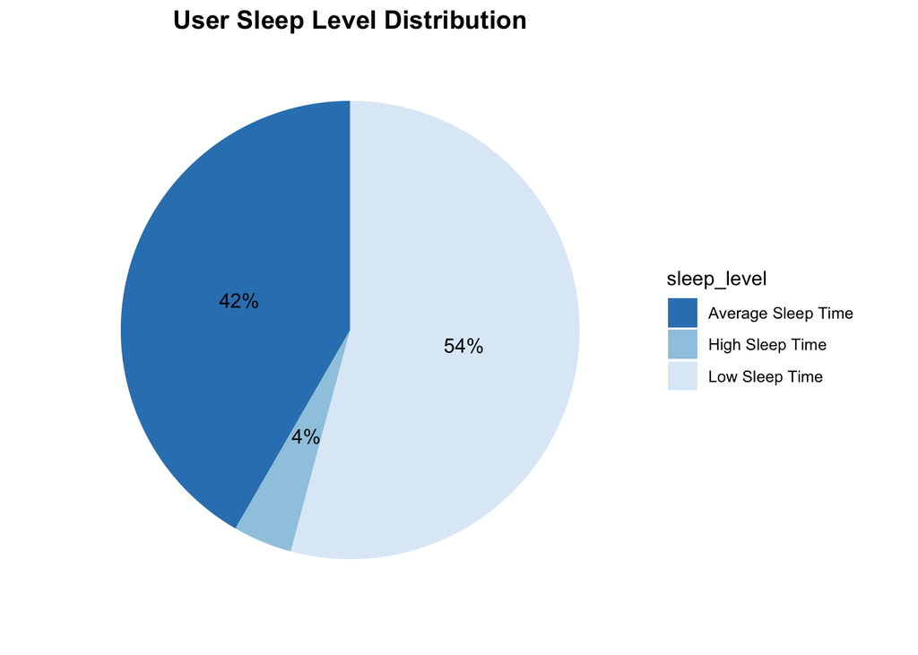

```r
sleep_plot <- ggplot(usr_sleep_dis, aes(x="", y=total_percent, fill=sleep_level))+
  geom_bar(width=1,stat="identity")+
  coord_polar("y", start=0)+
  scale_fill_brewer(palette="Blues", direction=-1)+
  theme_minimal()+
  theme(axis.text.x=element_blank(),
        axis.title.y = element_blank(),
        panel.border = element_blank(),
        panel.grid=element_blank(),
        axis.ticks = element_blank(),
        plot.title=element_text(size=14, face="bold", hjust = 0.5)
        )+
  geom_text(aes(label = labels), position = position_stack(vjust = 0.5))+
  labs(title="User Sleep Level Distribution", x="", y="")

sleep_plot
```

### 5.4 Device Wear Time

```r
usr_use <- daily_Activity_Sleep %>%
  group_by(id) %>%
  summarize(days_used=sum(n())) %>%
  mutate(usage = case_when(
    days_used >= 1 & days_used <= 5 ~ "Low Wear Time",
    days_used >= 6 & days_used <= 23 ~ "Moderate Wear Time",
    days_used >= 24 & days_used <= 31 ~ "High Wear Time",
  ))

head(usr_use)
```

```
## # A tibble: 6 × 3
##           id days_used usage
##        <dbl>     <int> <chr>
## 1 1503960366        25 High Wear Time
## 2 1644430081         4 Low Wear Time
## 3 1844505072         3 Low Wear Time
## 4 1927972279         5 Low Wear Time
## 5 2026352035        28 High Wear Time
## 6 2320127002         1 Low Wear Time
```

```r
usr_wear_dis <- usr_use %>%
  group_by(usage)%>%
  summarise(total=n())%>%
  mutate(total1=sum(total))%>%
  group_by(usage)%>%
  summarise(total_percent = total/total1)%>%
  mutate(labels = scales::percent(total_percent))

head(usr_wear_dis)
```

```
## # A tibble: 3 × 3
##   usage              total_percent labels
##   <chr>                      <dbl> <chr>
## 1 High Wear Time             0.458 46%
## 2 Low Wear Time              0.333 33%
## 3 Moderate Wear Time         0.208 21%
```

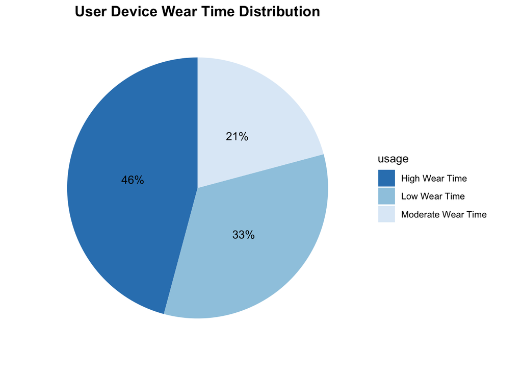

```r
wear_plot <- ggplot(usr_wear_dis, aes(x="", y=total_percent, fill=usage))+
  geom_bar(width=1,stat="identity")+
  coord_polar("y", start=0)+
  scale_fill_brewer(palette="Blues", direction=-1)+
  theme_minimal()+
  theme(axis.text.x=element_blank(),
        axis.title.y = element_blank(),
        panel.border = element_blank(),
        panel.grid=element_blank(),
        axis.ticks = element_blank(),
        plot.title=element_text(size=14, face="bold", hjust = 0.5)
        )+
  geom_text(aes(label = labels), position = position_stack(vjust = 0.5))+
  labs(title="User Device Wear Time Distribution", x="", y="")

wear_plot
```

## 6. Suggestions

Now is a time to look back at the Business tasks to provide a suggestion that would match Bellabeat’s vision.

### Sleep Reminder

From the above discoveries, we find that sleep is a category where the data shows the most lack of, as in lack of sleep time. Over half of the population are receiving less than 7 hours of sleep, which is below the recommended amount of around 8 hours. In this case, we can send out a reminder at a time where it will let the user know how to get the healthy and correct amount of sleep for the night.

### Active Alert

We can also introduce an active alert, telling the user to get the healthy amount of activity in within the day, and simply stand for a bit after sitting down for too long, which are both beneficial for the human body in the long run.